# Batch - C Group - 4

#### Prantik Singh Chauhan

```python
import pandas as pd
import numpy as np
import matplotlib.pyplot as plt
import seaborn as sns
```

```python
df = pd.DataFrame(pd.read_csv("hr_Hiring_details_with_joining_status_LOB.csv",index_col=0))
```

```python
df.head()
```

|  | Sno | Candidate Ref | DOJ Extended | Duration to accept offer | Notice period | Offered band | Pecent hike expected in CTC | Percent hike offered in CTC | Percent difference CTC | Joining Bonus | Candidate relocate actual | Gender | Candidate Source | Rex in Yrs | Location | Age | LOB_id | Status | LOB |
| --- | --- | --- | --- | --- | --- | --- | --- | --- | --- | --- | --- | --- | --- | --- | --- | --- | --- | --- | --- |
| 0 | 1 | 2110407 | Yes | 14 | 30 | E2 | -20.79 | 13.16 | 42.86 | No | No | Female | Agency | 7 | Noida | 34.0 | 1 | Joined | ERS |
| 1 | 2 | 2112635 | No | 18 | 30 | E2 | 50.00 | 320.00 | 180.00 | No | No | Male | Employee Referral | 8 | Chennai | 34.0 | 2 | Joined | INFRA |
| 2 | 3 | 2112838 | No | 3 | 45 | E2 | 42.84 | 42.84 | 0.00 | No | No | Male | Agency | 4 | Noida | 27.0 | 2 | Joined | INFRA |
| 3 | 4 | 2115021 | No | 26 | 30 | E2 | 42.84 | 42.84 | 0.00 | No | No | Male | Employee Referral | 4 | Noida | 34.0 | 2 | Joined | INFRA |
| 4 | 5 | 2115125 | Yes | 1 | 120 | E2 | 42.59 | 42.59 | 0.00 | No | Yes | Male | Employee Referral | 6 | Noida | 34.0 | 2 | Joined | INFRA |

```python
df.shape
```

```
(8995, 19)
```

```python
df.isnull().sum()
```

```
Sno                             0
Candidate Ref                   0
DOJ Extended                    0
Duration to accept offer        0
Notice period                   0
Offered band                   13
Pecent hike expected in CTC     0
Percent hike offered in CTC     0
Percent difference CTC          0
Joining Bonus                   0
Candidate relocate actual       0
Gender                          0
Candidate Source                0
Rex in Yrs                      0
Location                        0
Age                            15
LOB_id                          0
Status                          0
LOB                             0
dtype: int64
```

#### Removing null from offered band

```python
df['Offered band'].value_counts()
```

```
E1    5565
E2    2704
E3     502
E0     211
Name: Offered band, dtype: int64
```

#### As Offered Band is categorical column we will fill NaN with the mode(E1) of the data

```python
df['Offered band'].fillna('E1',inplace=True)
```

```python
df['Offered band'].value_counts()
```

```
E1    5578
E2    2704
E3     502
E0     211
Name: Offered band, dtype: int64
```

```python
df.isnull().sum()
```

```
Sno                             0
Candidate Ref                   0
DOJ Extended                    0
Duration to accept offer        0
Notice period                   0
Offered band                    0
Pecent hike expected in CTC     0
Percent hike offered in CTC     0
Percent difference CTC          0
Joining Bonus                   0
Candidate relocate actual       0
Gender                          0
Candidate Source                0
Rex in Yrs                      0
Location                        0
Age                            15
LOB_id                          0
Status                          0
LOB                             0
dtype: int64
```

#### Now to remove the null values from age

```python
df['Age'].value_counts()
```

```
34.0    2142
27.0     903
26.0     839
28.0     770
25.0     676
29.0     630
30.0     575
31.0     485
24.0     397
32.0     378
33.0     298
23.0     221
35.0     168
36.0     127
37.0      86
38.0      62
22.0      58
39.0      44
40.0      39
41.0      18
42.0      16
43.0      11
45.0       9
44.0       6
50.0       4
49.0       3
21.0       3
48.0       3
46.0       3
47.0       2
20.0       2
51.0       1
60.0       1
Name: Age, dtype: int64
```

```python
df['Age'].describe()
```

```
count    8980.000000
mean       29.912027
std         4.095699
min        20.000000
25%        27.000000
50%        29.000000
75%        34.000000
max        60.000000
Name: Age, dtype: float64
```

```python
df['Age'].median()
```

```
29.0
```

```python
df['Age'].fillna(df['Age'].median(),inplace=True)
```

```python
df.isnull().sum()
```

```
Sno                            0
Candidate Ref                  0
DOJ Extended                   0
Duration to accept offer       0
Notice period                  0
Offered band                   0
Pecent hike expected in CTC    0
Percent hike offered in CTC    0
Percent difference CTC         0
Joining Bonus                  0
Candidate relocate actual      0
Gender                         0
Candidate Source               0
Rex in Yrs                     0
Location                       0
Age                            0
LOB_id                         0
Status                         0
LOB                            0
dtype: int64
```

#### Now all the null values have been removed from the dataset

### 1. Analysis of percentage joined of offer released

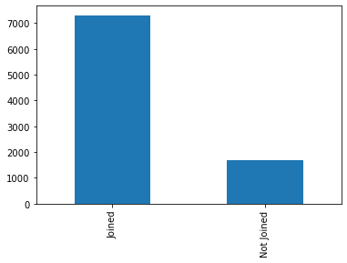

```python
df.Status.value_counts().plot(kind='bar')
```

```python
df.Status.value_counts(normalize=True)*100
```

```
Joined        81.300723
Not Joined    18.699277
Name: Status, dtype: float64
```

#### From the above data we can observe that 81% of the candidates joined the company

### 2. Key drivers influencing the status of candidate

```python
df.info()
```

```
<class 'pandas.core.frame.DataFrame'>
Int64Index: 8995 entries, 0 to 8994
Data columns (total 19 columns):
 #   Column                       Non-Null Count  Dtype
---  ------                       --------------  -----
 0   Sno                          8995 non-null   int64
 1   Candidate Ref                8995 non-null   int64
 2   DOJ Extended                 8995 non-null   object
 3   Duration to accept offer     8995 non-null   int64
 4   Notice period                8995 non-null   int64
 5   Offered band                 8995 non-null   object
 6   Pecent hike expected in CTC  8995 non-null   float64
 7   Percent hike offered in CTC  8995 non-null   float64
 8   Percent difference CTC       8995 non-null   float64
 9   Joining Bonus                8995 non-null   object
 10  Candidate relocate actual    8995 non-null   object
 11  Gender                       8995 non-null   object
 12  Candidate Source             8995 non-null   object
 13  Rex in Yrs                   8995 non-null   int64
 14  Location                     8995 non-null   object
 15  Age                          8995 non-null   float64
 16  LOB_id                       8995 non-null   int64
 17  Status                       8995 non-null   object
 18  LOB                          8995 non-null   object
dtypes: float64(4), int64(6), object(9)
memory usage: 1.4+ MB
```

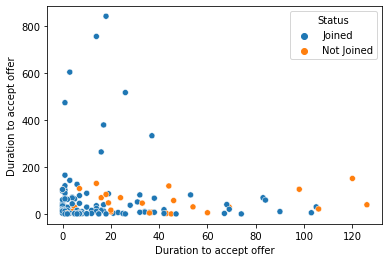

```python
sns.scatterplot(y= df['Duration to accept offer'].value_counts(),x= df['Duration to accept offer'],hue= df.Status)
```

```
From the above shown data we can observe the following:
    -> The candidates who has duration less than 20 days are most likely to join
    -> the candidates having the duration above 100 are most liket to not join
```

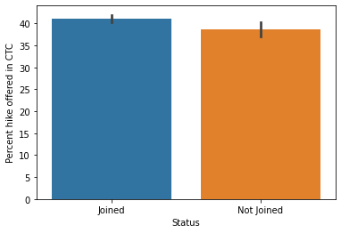

```python
sns.barplot(x= df['Status'], y= df['Percent hike offered in CTC'])
```

```python
s = df.groupby('Status')['Percent hike offered in CTC']
```

```python
s.describe()
```

| Status | count | mean | std | min | 25% | 50% | 75% | max |
| --- | --- | --- | --- | --- | --- | --- | --- | --- |
| Joined | 7313.0 | 41.133205 | 36.940232 | -60.00 | 22.2200 | 36.360 | 50.00 | 471.43 |
| Not Joined | 1682.0 | 38.588460 | 31.904401 | -60.53 | 22.0675 | 34.945 | 48.33 | 287.50 |

##### From the above data we can observe that the people who have joined the firm has almost 2% more hike.

```python
pd.crosstab(df.Status,df['Joining Bonus'])
```

| Joining Bonus Status | No | Yes |
| --- | --- | --- |
| Joined | 6977 | 336 |
| Not Joined | 1601 | 81 |

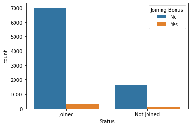

```python
sns.countplot(x=df.Status,hue= df['Joining Bonus'])
```

##### From the above graph we can observe that Joining bonus doesn't play as a key driver for the person to join the company.

As most of the people didn't has joining bonus but still joined the company

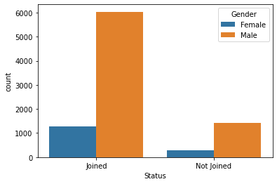

```python
sns.countplot(x=df.Status,hue= df['Gender'])
```

```python
pd.crosstab(df.Status,df['Gender'])
```

| Gender Status | Female | Male |
| --- | --- | --- |
| Joined | 1278 | 6035 |
| Not Joined | 273 | 1409 |

##### The data provided shows that the ratio of female and male joining are equal, Hence we can observe gender doesn't play a role in influencing the joining status of a candidate.

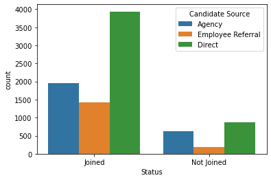

```python
sns.countplot(x=df.Status,hue= df['Candidate Source'])
```

```python
pd.crosstab(df.Status,df['Candidate Source'])
```

| Candidate Source Status | Agency | Direct | Employee Referral |
| --- | --- | --- | --- |
| Joined | 1960 | 3937 | 1416 |
| Not Joined | 625 | 864 | 193 |

According to the observation candidate source the chances of candidate joining the company is greater if he comes from employee referral.

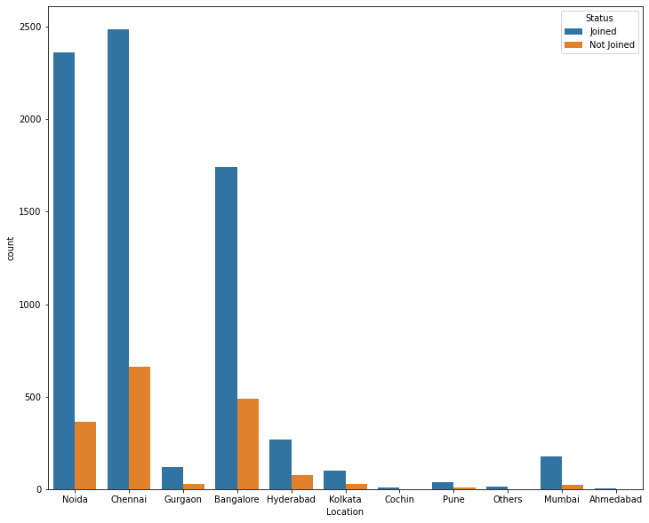

```python
fig,ax = plt.subplots(figsize=(12,10))
sns.countplot(x=df.Location,hue = df.Status, ax=ax)
```

```python
pd.crosstab(df.Status,df['Location'])
```

| Location Status | Ahmedabad | Bangalore | Chennai | Cochin | Gurgaon | Hyderabad | Kolkata | Mumbai | Noida | Others | Pune |
| --- | --- | --- | --- | --- | --- | --- | --- | --- | --- | --- | --- |
| Joined | 5 | 1742 | 2486 | 7 | 118 | 266 | 100 | 176 | 2362 | 13 | 38 |
| Not Joined | 1 | 488 | 664 | 1 | 28 | 75 | 29 | 21 | 365 | 0 | 10 |

#### Location is not influencing the the joining status as for each city we can observe that candidate joining and not joining are almost in same ratio

```python
pd.crosstab(df.Status,df['Age'])
```

| Age Status | 20.0 | 21.0 | 22.0 | 23.0 | 24.0 | 25.0 | 26.0 | 27.0 | 28.0 | 29.0 | ... | 43.0 | 44.0 | 45.0 | 46.0 | 47.0 | 48.0 | 49.0 | 50.0 | 51.0 | 60.0 |
| --- | --- | --- | --- | --- | --- | --- | --- | --- | --- | --- | --- | --- | --- | --- | --- | --- | --- | --- | --- | --- | --- |
| Joined | 1 | 3 | 48 | 182 | 342 | 547 | 647 | 704 | 587 | 517 | ... | 10 | 5 | 8 | 2 | 2 | 3 | 2 | 4 | 0 | 0 |
| Not Joined | 1 | 0 | 10 | 39 | 55 | 129 | 192 | 199 | 183 | 128 | ... | 1 | 1 | 1 | 1 | 0 | 0 | 1 | 0 | 1 | 1 |

2 rows × 33 columns

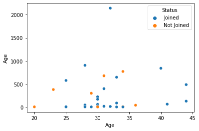

```python
sns.scatterplot(y= df.Age.value_counts(),x= df.Age,hue= df.Status)
```

[output not shown]